# RFID Particle-Tracking Method Walkthrough

Matt Jenkin

February 2024

## Purpose

This repository is a minimal, reusable example of the computational method used in Jenkin et al. (2023), *Tracking coarse sediment in an Alpine subglacial channel using radio-tagged particles*. It does not reproduce every analysis in the paper. Instead, it shows how roving and stationary active-RFID antenna records can be turned into a time series of particle transport distance with uncertainty.

The workflow mirrors the method phases in the paper:

1. prepare roving RFID, dGNSS, particle, channel and antenna inputs;
2. weight roving detections using survey effort and signal strength;
3. estimate particle locations and uncertainty with KDE;
4. convert planimetric locations to along-channel transport distance;
5. convert stationary antenna detections to reach-scale time constraints;
6. combine roving and stationary records.

The full paper and supporting information are included as:

- `JOG2300077.PDF`
- `JOG2300077_SI.pdf`

The minimal example starts from cleaned inputs in `data/`:

- `roving_antenna.gpkg`: roving RFID detections with dGNSS antenna positions;
- `dGNSS.gpkg`: one-second roving antenna survey positions;
- `tags.csv`: tagged particle metadata and deployment times;
- `survey_times.csv`: representative survey time for each survey day;
- `channel_line.gpkg`: estimated transport path;
- `antennas.gpkg`: stationary antenna positions;
- `stationary_antennas.csv`: stationary antenna in/out detections;
- `glacier_outline.gpkg`: context geometry for plotting.

To adapt the method elsewhere, the most important site-specific assumptions are the coordinate reference system, channel centreline, survey extent, grid size, seeding location and stationary antenna detection range.

Particle metadata such as deployment time, mass and grain-size axes are stored once in `tags.csv` and joined into the workflow when required.

```r
source("scripts/00_setup.R")
```

## Roving Antenna Heuristic

The roving antenna produces a point cloud of received transmissions for each particle on each survey day. A raw point density can be biased by survey effort: the antenna may spend longer in one part of the grid than another.

The heuristic used here combines:

- the number of detections in each grid cell;
- mean received signal strength (`RSSI`) in each grid cell;
- the time spent surveying each grid cell.

This produces a relative weighting surface used in the KDE localisation step.

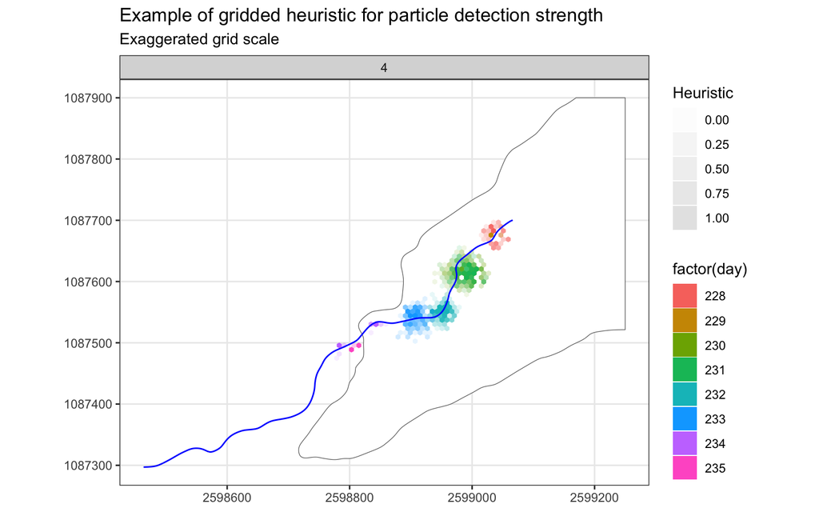

```r
source("scripts/01_roving_heuristic.R")
heuristic_plot
```

## KDE Localisation

For each particle-day combination, the weighted roving detections are smoothed using kernel density estimation. The maximum-density location is treated as the most likely planimetric particle position. The 95% contour is retained as a spatial uncertainty estimate.

Small or failed contours are replaced by a conservative circular buffer around the point estimate. This keeps the downstream distance workflow explicit about uncertainty rather than silently dropping difficult cases.

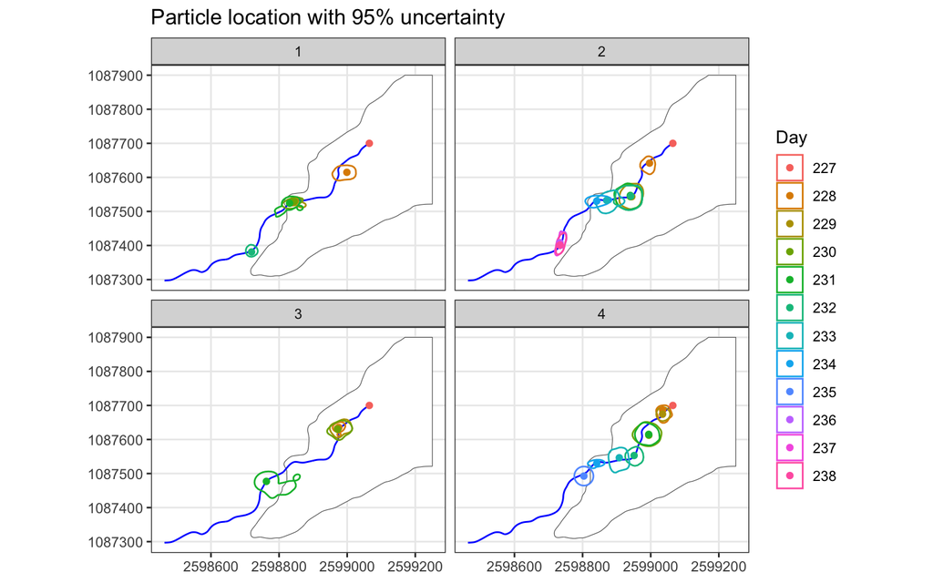

```r
source("scripts/02_kde_localisation.R")
location_plot
```

## Along-Channel Distance

The method converts each planimetric point and its uncertainty contour to distance along the estimated channel centreline. This step is what turns a map location into a sediment transport time series.

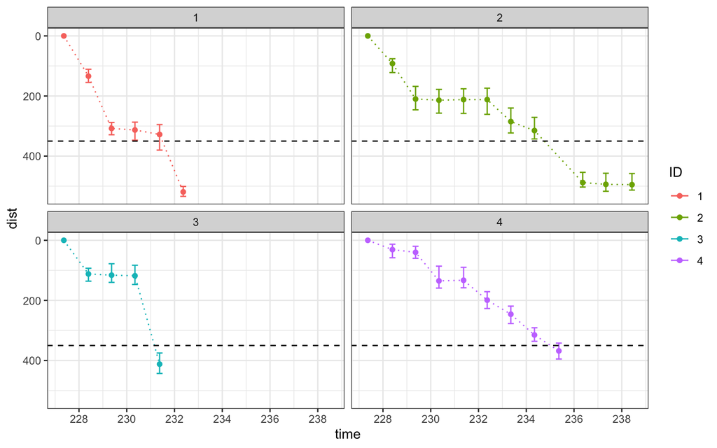

```r
distance_plot
```

## Stationary Antennas

Stationary antennas provide a complementary Eulerian record: they constrain when particles passed through fixed channel reaches. Here, each antenna is buffered by an approximate horizontal detection range and intersected with the channel centreline to estimate the along-channel reach covered by that antenna.

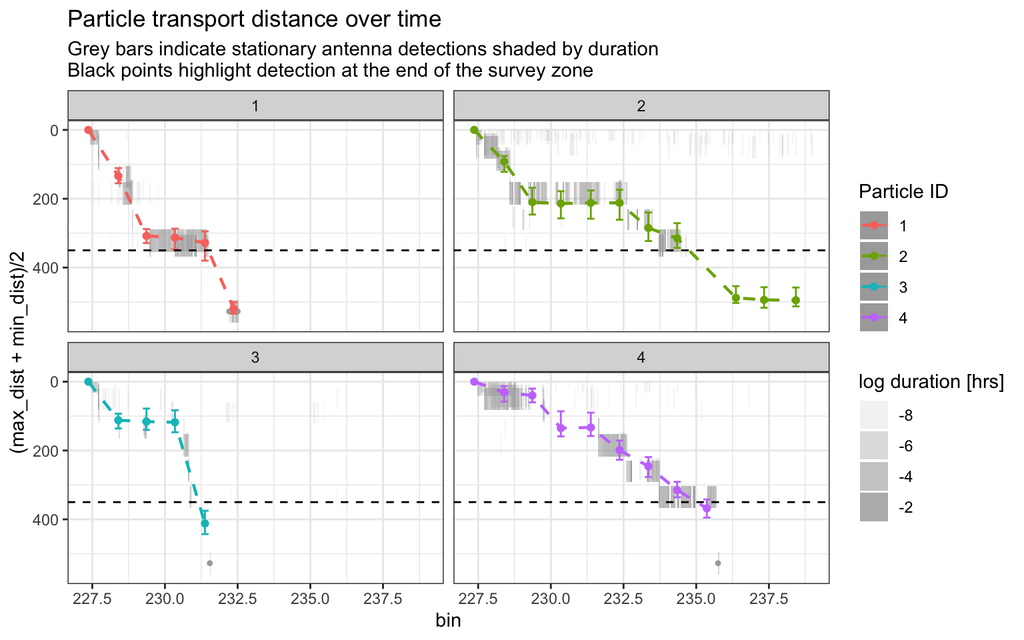

```r
source("scripts/03_stationary_antennas.R")
combined_plot
```

## Combined Output

The final table combines:

- roving antenna point estimates and uncertainty bounds;
- stationary antenna reach detections and durations.

```r
source("scripts/04_combine_records.R")
dplyr::glimpse(combi)
```

```
## Rows: 787
## Columns: 7
## $ ID       <dbl> 1, 1, 1, 1, 1, 1, 1, 1, 1, 1, 1, 1, 1, 1, 1, 1, 1, 1, 1, 1, 1…
## $ time     <dbl> 227.3646, 227.4167, 227.4583, 227.4583, 227.4583, 227.5000, 2…
## $ dist     <dbl> 0, NA, NA, NA, NA, NA, NA, NA, NA, NA, NA, NA, NA, NA, NA, NA…
## $ min_dist <dbl> NA, 0, 0, 0, 152, 0, 0, 0, 0, 152, 0, 0, 0, 0, 0, 0, 0, 9, 18…
## $ max_dist <dbl> NA, 42, 32, 42, 218, 32, 42, 32, 42, 218, 32, 42, 32, 42, 32,…
## $ duration <dbl> NA, 0.0113773148, 0.0028472222, 0.0109953704, 0.0002430556, 0…
## $ system   <chr> "rov", "stat", "stat", "stat", "stat", "stat", "stat", "stat"…
```

The generated CSV files are written to `outputs/`:

- `roving_transport_distances.csv`
- `stationary_transport_records.csv`
- `combined_transport_records.csv`

## Reuse Notes

This method is intended as a template, not a black box. For another field site, review these assumptions before reuse:

- the CRS and units must be metric;
- the channel centreline must represent the expected transport path;
- the grid size should reflect survey density and detection range;
- RSSI may not scale with distance in the same way at every site;
- the KDE bandwidth choice should be re-evaluated for new survey geometry;
- stationary antenna detection ranges should be calibrated or justified.

The purpose of the capsule is to make the computational logic transparent enough that readers can reproduce the example and adapt the method deliberately.